# group_assignment(daily)

张雨晴 韩思越 林耿 王众 陆静颐

2019/3/30

#二、总播放量相关因素分析 我们将截止到8日的总播放量作为因变量，以好评数、差评数、评分、剧种作为自变量，进行了线性回归，得到的结果如下。

```r
setwd("C:/Users/Administrator/Desktop/data mining")
dat = read.csv("d8_all.csv", header = T, stringsAsFactors = F)
llg = lm(播放量~好评数+差评数+评分+喜剧+网络剧+家庭剧+言情剧+军旅剧+青春剧+谍战剧+偶像剧+古装剧+罪案剧+年代剧+宫廷剧+武侠剧+悬疑剧+历史剧+科幻剧+农村剧+神话剧+粤语电视剧+穿越剧, data = dat)
summary(llg)
```

```
##
## Call:
## lm(formula = 播放量 ~ 好评数 + 差评数 + 评分 + 喜剧 + 网络剧 +
##     家庭剧 + 言情剧 + 军旅剧 + 青春剧 + 谍战剧 + 偶像剧 + 古装剧 +
##     罪案剧 + 年代剧 + 宫廷剧 + 武侠剧 + 悬疑剧 + 历史剧 + 科幻剧 +
##     农村剧 + 神话剧 + 粤语电视剧 + 穿越剧, data = dat)
##
## Residuals:
##    Min     1Q Median     3Q    Max
## -91650  -8282  -3506   5801 120629
##
## Coefficients:
##               Estimate Std. Error t value Pr(>|t|)
## (Intercept) -2.966e+04  1.653e+04  -1.794  0.07444 .
## 好评数       4.399e-02  9.749e-03   4.512 1.15e-05 ***
## 差评数       1.396e-01  5.105e-02   2.734  0.00688 **
## 评分         4.398e+03  2.047e+03   2.148  0.03303 *
## 喜剧         1.258e+04  6.187e+03   2.033  0.04347 *
## 网络剧      -1.103e+04  6.135e+03  -1.798  0.07379 .
## 家庭剧       2.122e+03  5.739e+03   0.370  0.71206
## 言情剧       7.932e+03  4.662e+03   1.702  0.09055 .
## 军旅剧       8.243e+03  5.274e+03   1.563  0.11983
## 青春剧      -4.743e+03  5.467e+03  -0.868  0.38679
## 谍战剧       1.306e+03  5.733e+03   0.228  0.82008
## 偶像剧      -4.690e+03  4.696e+03  -0.999  0.31927
## 古装剧       2.459e+03  7.695e+03   0.320  0.74964
## 罪案剧       2.512e+04  9.846e+03   2.552  0.01155 *
## 年代剧       4.148e+03  4.841e+03   0.857  0.39269
## 宫廷剧      -7.096e+03  1.235e+04  -0.574  0.56634
## 武侠剧       1.657e+03  9.361e+03   0.177  0.85968
## 悬疑剧      -8.551e+02  6.192e+03  -0.138  0.89032
## 历史剧      -1.327e+03  7.797e+03  -0.170  0.86505
## 科幻剧       2.670e+03  1.666e+04   0.160  0.87287
## 农村剧       4.048e+03  1.205e+04   0.336  0.73731
## 神话剧       1.341e+04  1.466e+04   0.915  0.36146
## 粤语电视剧  -3.762e+03  2.422e+04  -0.155  0.87671
## 穿越剧      -7.569e+04  2.537e+04  -2.983  0.00324 **
## ---
## Signif. codes:  0 '***' 0.001 '**' 0.01 '*' 0.05 '.' 0.1 ' ' 1
##
## Residual standard error: 22830 on 181 degrees of freedom
## Multiple R-squared:  0.8756, Adjusted R-squared:  0.8598
## F-statistic:  55.4 on 23 and 181 DF,  p-value: < 2.2e-16
```

在初始的模型中，可以看到好评数、差评数、评分、喜剧、罪案剧、穿越剧与播放量的线性关系比较显著，此时Multiple R-squared的值为0.8756，Adjusted R-squared的值为0.8598。

经过对变量的筛选，每次将系数p值最大的一项变量移除出线性回归模型，并重新进行回归，直到所有变量的p值小于0.1。 得到的最终模型如下：

```r
dat = read.csv("d8_all.csv", header = T, stringsAsFactors = F)
llg = lm(播放量~好评数+差评数+评分+喜剧+网络剧+罪案剧+穿越剧, data = dat)
summary(llg)
```

```
##
## Call:
## lm(formula = 播放量 ~ 好评数 + 差评数 + 评分 + 喜剧 + 网络剧 +
##     罪案剧 + 穿越剧, data = dat)
##
## Residuals:
##    Min     1Q Median     3Q    Max
## -93161  -7724  -3039   5578 127306
##
## Coefficients:
##               Estimate Std. Error t value Pr(>|t|)
## (Intercept) -1.611e+04  1.395e+04  -1.155 0.249312
## 好评数       3.744e-02  9.005e-03   4.158 4.79e-05 ***
## 差评数       1.726e-01  4.742e-02   3.640 0.000349 ***
## 评分         3.345e+03  1.782e+03   1.877 0.062017 .
## 喜剧         9.541e+03  5.488e+03   1.738 0.083696 .
## 网络剧      -1.667e+04  5.064e+03  -3.291 0.001183 **
## 罪案剧       2.449e+04  9.272e+03   2.641 0.008929 **
## 穿越剧      -7.114e+04  2.434e+04  -2.923 0.003869 **
## ---
## Signif. codes:  0 '***' 0.001 '**' 0.01 '*' 0.05 '.' 0.1 ' ' 1
##
## Residual standard error: 22360 on 197 degrees of freedom
## Multiple R-squared:  0.8701, Adjusted R-squared:  0.8655
## F-statistic: 188.6 on 7 and 197 DF,  p-value: < 2.2e-16
```

若进行log处理，经过变量筛选后得到的模型如下：

```r
dat = read.csv("d8_all.csv", header = T, stringsAsFactors = F)
llg2 = lm(log(播放量)~好评数+评分+网络剧+言情剧+军旅剧+偶像剧, data = dat)
summary(llg2)
```

```
##
## Call:
## lm(formula = log(播放量) ~ 好评数 + 评分 + 网络剧 + 言情剧 +
##     军旅剧 + 偶像剧, data = dat)
##
## Residuals:
##     Min      1Q  Median      3Q     Max
## -4.1649 -0.7235  0.1480  0.9303  2.5842
##
## Coefficients:
##               Estimate Std. Error t value Pr(>|t|)
## (Intercept)  3.589e+00  7.260e-01   4.944 1.62e-06 ***
## 好评数       8.651e-07  1.149e-07   7.531 1.75e-12 ***
## 评分         6.580e-01  9.209e-02   7.145 1.68e-11 ***
## 网络剧      -1.160e+00  2.692e-01  -4.310 2.57e-05 ***
## 言情剧       7.727e-01  2.097e-01   3.684 0.000296 ***
## 军旅剧       5.751e-01  2.543e-01   2.262 0.024792 *
## 偶像剧      -7.302e-01  2.316e-01  -3.153 0.001869 **
## ---
## Signif. codes:  0 '***' 0.001 '**' 0.01 '*' 0.05 '.' 0.1 ' ' 1
##
## Residual standard error: 1.225 on 198 degrees of freedom
## Multiple R-squared:  0.5418, Adjusted R-squared:  0.5279
## F-statistic: 39.02 on 6 and 198 DF,  p-value: < 2.2e-16
```

该模型的拟合度并不如原本的模型，所以仍选择原本的模型。

我们进行了交叉变量的分析，可以发现几个较为显著的变量。（由于变量较多，我们仅提取了Pr值低于5%的交叉变量，省略了其他变量）  
Estimate Std. Error t value Pr(>|t|)  
言情剧:古装剧 33798.4 12084.2 2.797 0.00596 **  
言情剧:宫廷剧 -40788.5 14322.0 -2.848 0.00513 **  
言情剧:武侠剧 -35999.1 13434.5 -2.680 0.00835 **  
青春剧:偶像剧 8118.8 3429.0 2.368 0.01941 *  
古装剧:武侠剧 -27562.0 9016.1 -3.057 0.00273 **  
—  
Signif. codes: 0 ‘**’ 0.001 ‘**’ 0.01 ‘’ 0.05 ‘.’ 0.1 ‘ ’ 1

如，对于电视剧类型同为言情剧和古装剧的变量，我们在1%的显著水平下认为播放量与这一交叉变量有较好的正相关性，即，同时为言情剧和古装剧的电视剧的播放量会比其他电视剧高；另外，在1%的显著水平下，同为古装剧和武侠剧、同为言情剧和宫廷剧、同为言情剧和武侠剧，都与播放量呈负相关性，我们可以认为，这些类型的剧目在市场上较多，造成观众的审美疲劳，以至于对播放量造成负作用；最后，在2%的显著水平下，同为青春剧和偶像剧的电视剧的播放量会高于其他剧种，这种类型的电视剧在目前确实占据比较大的市场。

#三、日播放量相关因素分析 读取数据

```r
library(readxl)
dat1<- read_xlsx("tv02.xlsx")
```

日期做分类处理

```r
dat1$holiday <- as.character("非国庆")
A <- dat1$日期 == 1 | dat1$日期 == 2 | dat1$日期 == 3 | dat1$日期 == 4 | dat1$日期 == 5 | dat1$日期 == 6 | dat1$日期 == 7
dat1$holiday[A] <- "国庆"

dat1$weekend <- as.character("非周末")
B <- dat1$日期 == 26 | dat1$日期 == 27
dat1$weekend[B] <- "周末"
```

回归

```r
lm.sol <-lm(formula = `日播放量（万）` ~ 日好评数+日差评数+评分+holiday+weekend,data=dat1)
summary(lm.sol)
```

```
##
## Call:
## lm(formula = `日播放量（万）` ~ 日好评数 + 日差评数 + 评分 +
##     holiday + weekend, data = dat1)
##
## Residuals:
##     Min      1Q  Median      3Q     Max
## -3472.2   -44.3   -26.4    12.0  4518.0
##
## Coefficients:
##               Estimate Std. Error t value Pr(>|t|)
## (Intercept) -7.157e+01  3.301e+01  -2.168  0.03020 *
## 日好评数     6.662e-02  9.333e-04  71.378  < 2e-16 ***
## 日差评数    -9.277e-03  6.614e-03  -1.403  0.16082
## 评分         1.361e+01  4.253e+00   3.199  0.00139 **
## holiday国庆  1.025e+01  1.011e+01   1.014  0.31056
## weekend周末 -5.473e+01  1.497e+01  -3.656  0.00026 ***
## ---
## Signif. codes:  0 '***' 0.001 '**' 0.01 '*' 0.05 '.' 0.1 ' ' 1
##
## Residual standard error: 267.9 on 3227 degrees of freedom
##   (1 observation deleted due to missingness)
## Multiple R-squared:  0.8279, Adjusted R-squared:  0.8277
## F-statistic:  3105 on 5 and 3227 DF,  p-value: < 2.2e-16
```

删掉每一个剧名出现的第一次，记之后的数据为dat3

```r
dat1$name <- as.character("")

for (i in c(2:3233))
{
  if(dat1$剧名[i] != dat1$剧名[i-1])
    dat1$name[i] <- "a"
  else
    dat1$name[i] <- "b"
}

dat3 <- dat1
dat3$name[dat3$name=="a"] <- NA
dat3 <- na.omit(dat3)
```

```r
lm.sol1 <-lm(formula = `日播放量（万）` ~ 日好评数,data=dat3)
lm.sol2 <-lm(formula = `日播放量（万）` ~ 前一日好评数,data=dat3)
summary(lm.sol1)
```

```
##
## Call:
## lm(formula = `日播放量（万）` ~ 日好评数, data = dat3)
##
## Residuals:
##     Min      1Q  Median      3Q     Max
## -3552.4   -33.6   -29.2   -17.9  4584.4
##
## Coefficients:
##              Estimate Std. Error t value Pr(>|t|)
## (Intercept) 3.065e+01  5.162e+00   5.937 3.23e-09 ***
## 日好评数    6.576e-02  5.492e-04 119.732  < 2e-16 ***
## ---
## Signif. codes:  0 '***' 0.001 '**' 0.01 '*' 0.05 '.' 0.1 ' ' 1
##
## Residual standard error: 278 on 3018 degrees of freedom
## Multiple R-squared:  0.8261, Adjusted R-squared:  0.826
## F-statistic: 1.434e+04 on 1 and 3018 DF,  p-value: < 2.2e-16
```

```r
summary(lm.sol2)
```

```
##
## Call:
## lm(formula = `日播放量（万）` ~ 前一日好评数, data = dat3)
##
## Residuals:
##     Min      1Q  Median      3Q     Max
## -3955.4   -38.4   -34.5   -22.6  4953.1
##
## Coefficients:
##               Estimate Std. Error t value Pr(>|t|)
## (Intercept)  3.604e+01  5.812e+00     6.2  6.4e-10 ***
## 前一日好评数 6.494e-02  6.292e-04   103.2  < 2e-16 ***
## ---
## Signif. codes:  0 '***' 0.001 '**' 0.01 '*' 0.05 '.' 0.1 ' ' 1
##
## Residual standard error: 313.2 on 3018 degrees of freedom
## Multiple R-squared:  0.7793, Adjusted R-squared:  0.7792
## F-statistic: 1.065e+04 on 1 and 3018 DF,  p-value: < 2.2e-16
```

R-squared 接近 0.8，说明回归情况比较理想。日播放量和前一日好评数有很密切的关系。

从原始数据中提取从24日开始每天都有非零日播放量数据的剧（零日播放量会导致较大的误差），记为dat4

```r
dat4 <- dat1[dat1$日期 != 23, ]
dat4 <- dat4[dat4$`日播放量（万）` > 0, ]
counts <- c()
for (i in c(1:2087))
{
  a <- dat4$剧名[i]
  n <- dim(dat4[dat4$剧名 == a, ])[1]
  counts <- c(counts, n)
}
dat4$counts <- counts
dat4 <- dat4[dat4$counts == 16, ]
```

回归

```r
lm.sol <-lm(formula = `日播放量（万）` ~ 日好评数 + 日差评数 + 评分 + holiday + weekend, data = dat4)
summary(lm.sol)
```

```
##
## Call:
## lm(formula = `日播放量（万）` ~ 日好评数 + 日差评数 + 评分 +
##     holiday + weekend, data = dat4)
##
## Residuals:
##     Min      1Q  Median      3Q     Max
## -2899.1   -78.5   -40.7     2.9  3433.2
##
## Coefficients:
##               Estimate Std. Error t value Pr(>|t|)
## (Intercept) -2.131e+02  7.805e+01  -2.730 0.006430 **
## 日好评数     5.467e-02  3.019e-03  18.109  < 2e-16 ***
## 日差评数     1.931e-02  1.726e-02   1.118 0.263728
## 评分         3.699e+01  9.920e+00   3.729 0.000203 ***
## holiday国庆  1.586e+00  2.320e+01   0.068 0.945505
## weekend周末 -7.074e+01  3.398e+01  -2.082 0.037587 *
## ---
## Signif. codes:  0 '***' 0.001 '**' 0.01 '*' 0.05 '.' 0.1 ' ' 1
##
## Residual standard error: 349.9 on 1059 degrees of freedom
## Multiple R-squared:  0.7429, Adjusted R-squared:  0.7416
## F-statistic: 611.9 on 5 and 1059 DF,  p-value: < 2.2e-16
```

R-squared > 0.7，说明回归情况比较理想。  
可以看出 日播放量和日好评数、是否是周末关系密切。好评数越高，播放量越高。  
然而与差评数的关系却并不大，究其原因，我们认为，差评数相比好评数有两面性，一方面差评数很高的确代表很多人不喜欢这部剧，但是正因为这部剧的播放量大才会导致它的差评数多，试想一部无人问津的剧，任凭它再烂，他又能有多少差评呢？

再从dat4中删除24日的数据，因为前一日好评数只有两个小时的间隔时长，避免影响结果，记为dat5

```r
dat5 <- dat4[dat4$日期 != 24, ]
```

```r
lm.sol1 <-lm(formula = `日播放量（万）` ~ 日好评数, data = dat5)
lm.sol2 <-lm(formula = `日播放量（万）` ~ 前一日好评数, data = dat5)
summary(lm.sol1)
```

```
##
## Call:
## lm(formula = `日播放量（万）` ~ 日好评数, data = dat5)
##
## Residuals:
##     Min      1Q  Median      3Q     Max
## -2883.1   -59.9   -57.4   -41.6  3422.7
##
## Coefficients:
##              Estimate Std. Error t value Pr(>|t|)
## (Intercept) 61.223050  11.226502   5.453 6.24e-08 ***
## 日好评数     0.059475   0.001101  54.032  < 2e-16 ***
## ---
## Signif. codes:  0 '***' 0.001 '**' 0.01 '*' 0.05 '.' 0.1 ' ' 1
##
## Residual standard error: 343.7 on 992 degrees of freedom
## Multiple R-squared:  0.7464, Adjusted R-squared:  0.7461
## F-statistic:  2919 on 1 and 992 DF,  p-value: < 2.2e-16
```

```r
summary(lm.sol2)
```

```
##
## Call:
## lm(formula = `日播放量（万）` ~ 前一日好评数, data = dat5)
##
## Residuals:
##     Min      1Q  Median      3Q     Max
## -3283.8   -57.8   -55.5   -39.7  3528.3
##
## Coefficients:
##               Estimate Std. Error t value Pr(>|t|)
## (Intercept)  59.282126  11.360950   5.218  2.2e-07 ***
## 前一日好评数  0.056156   0.001055  53.245  < 2e-16 ***
## ---
## Signif. codes:  0 '***' 0.001 '**' 0.01 '*' 0.05 '.' 0.1 ' ' 1
##
## Residual standard error: 347.5 on 992 degrees of freedom
## Multiple R-squared:  0.7408, Adjusted R-squared:  0.7405
## F-statistic:  2835 on 1 and 992 DF,  p-value: < 2.2e-16
```

接下来，我们使用corrplot包绘制相关性图：

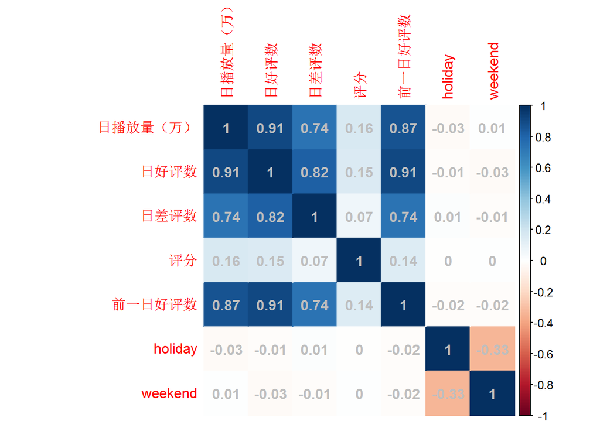

```r
library(corrplot)
dat5 <- dat1
dat5 <- dat5[,-1]
dat5 <- dat5[,-9]
dat5 <- dat5[,-5]

dat5$holiday[dat5$holiday == "非国庆"] <- "1"
dat5$holiday[dat5$holiday == "国庆"] <- "0"
dat5$holiday <- as.double(dat5$holiday)

dat5$weekend[dat5$weekend == "非周末"] <- "1"
dat5$weekend[dat5$weekend == "周末"] <- "0"
dat5$weekend <- as.double(dat5$weekend)

dat5<-na.omit(dat5)
M <- cor(dat5)
corrplot(M, method = "color",addCoef.col = "grey")
```